# Coursera Data Science Capstone - Week 2 Milestone Report

Vincent

March 2019

## Introduction

This report explores the data that we will use to build a predictive text analytics model. This data is provided by Swiftkey, a company that builds a smart keyboard that makes it easier for people to type on their mobile device. Swiftkey, Predictive text analytics. The data is from a corpus called HC Corpora. Our goal is to transform a corpus of text in a text prediction program.

In order to do so, we will have to follow several steps:

- Tokenization
- Handle punctualtion
- Handle digits
- Handle case (upper/lower)
- Handle wrong spelling
- Filter Profanity

The first step, however, is to load the data and perform explore basic indicators like word count, line count and simple plots/

## Downloading the training dataset

```r
DataURL <- "https://d396qusza40orc.cloudfront.net/dsscapstone/dataset/Coursera-SwiftKey.zip"
DataFile <- "Coursera-SwiftKey.zip"
if (!file.exists(DataFile)) {
  download.file(DataURL, destfile = DataFile)
  unzip(DataFile)
}
```

## Load useful libraries

```r
library(stringi)
library(ggplot2)
```

## Loading the English data in

### Blog data

```r
en_blog <- readLines("final/en_US/en_US.blogs.txt")
stri_stats_general(en_blog)
```

```
##       Lines LinesNEmpty       Chars CharsNWhite
##      899288      899288   208361438   171926076
```

```r
en_blog_words <- stri_count_words(en_blog)
summary(en_blog_words)
```

```
##    Min. 1st Qu.  Median    Mean 3rd Qu.    Max.
##    0.00    9.00   29.00   42.43   61.00 6726.00
```

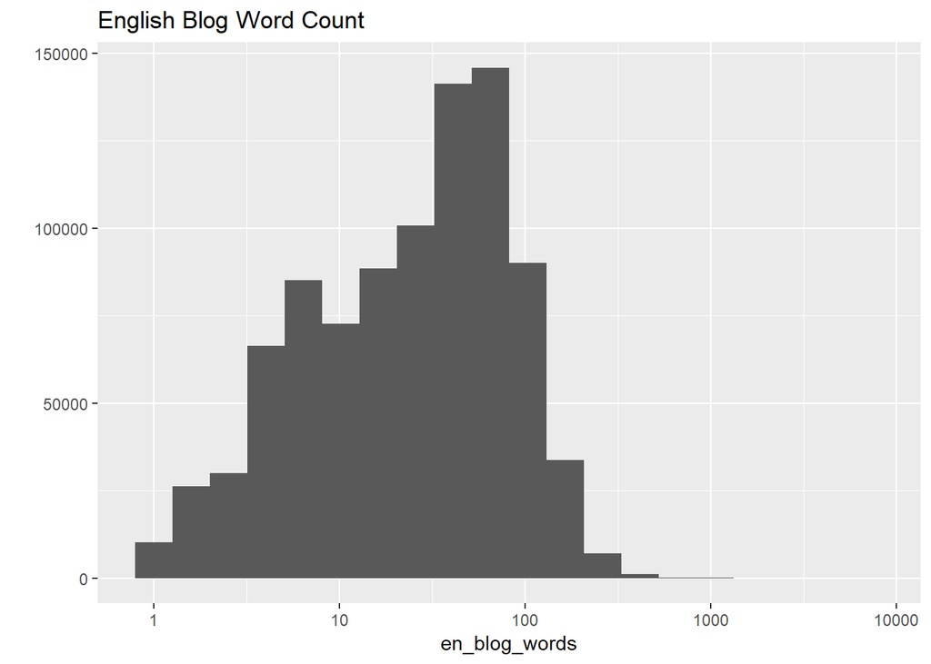

```r
qplot(en_blog_words, main = "English Blog Word Count", bins = 20) + scale_x_log10()
```

### News data

```r
en_news <- readLines("final/en_US/en_US.news.txt")
stri_stats_general(en_news)
```

```
##       Lines LinesNEmpty       Chars CharsNWhite
##       77259       77259    15683765    13117038
```

```r
en_news_words <- stri_count_words(en_news)
summary(en_news_words)
```

```
##    Min. 1st Qu.  Median    Mean 3rd Qu.    Max.
##    1.00   19.00   32.00   34.87   46.00 1123.00
```

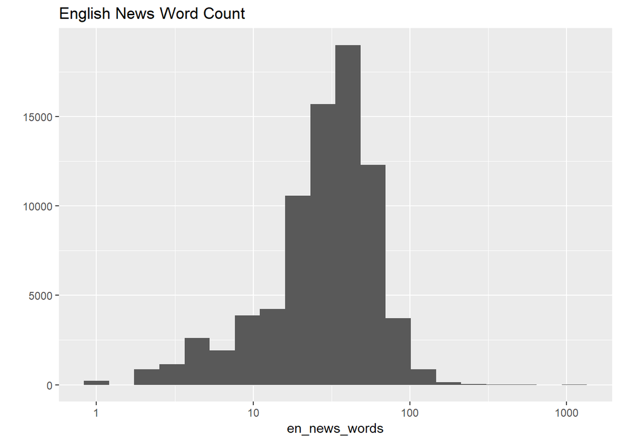

```r
qplot(en_news_words, main = "English News Word Count", bins = 20) + scale_x_log10()
```

### Twitter data

```r
en_twitter <- readLines("final/en_US/en_US.twitter.txt")
stri_stats_general(en_twitter)
```

```
##       Lines LinesNEmpty       Chars CharsNWhite
##     2360148     2360148   162384825   134370864
```

```r
en_twitter_words <- stri_count_words(en_twitter)
summary(en_twitter_words)
```

```
##    Min. 1st Qu.  Median    Mean 3rd Qu.    Max.
##     1.0     7.0    12.0    12.8    18.0    60.0
```

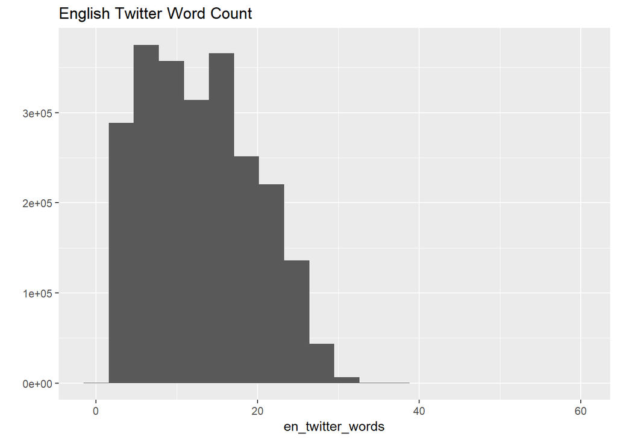

```r
qplot(en_twitter_words, main = "English Twitter Word Count", bins = 20)
```

Regarding twitter data, unlike blog and news data, the work count is more limited, probably because os the 140 character limit in a tweet.

## Word frequency for twitter data

### Step 1 - Clean and tokenize

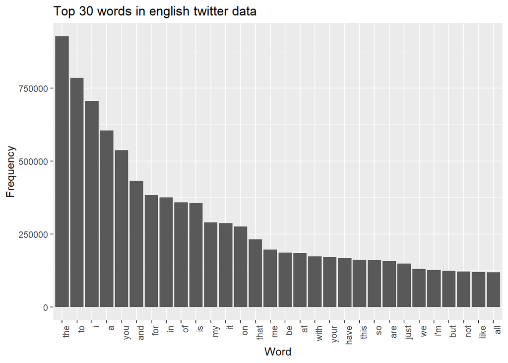

```r
# Remove punctuation and special characters
words <- gsub("#|\\?|;|!|:|\\)|\\(|\\.|&|,", "", en_twitter)
words <- trimws(words)

# convert to lower case
words <- tolower(words)

# Isolate single words
words <- unlist(strsplit(words, "\\s"))

freq <- data.frame(table(words))
freq <- freq[freq$words != "",]
freq <- freq[order(-freq$Freq),]

top <- head(freq, 30)
top$words <- factor(top$words, levels = top$words[order(-top$Freq)])

ggplot(top, aes(top$words, top$Freq)) + geom_bar(stat='identity') + theme(axis.text.x = element_text(angle = 90, hjust = 1)) + labs(title = "Top 30 words in english twitter data", x = "Word", y = "Frequency")
```

## Next steps

The next steps will be to transform this data (tokenisation, profanity filtering, punctuation removal, etc.) and use it to build a predictive algorithm able to predict the next word form the 1, 2 or three previous words. This algorithm will then be integrated in a Shiny application, evaluated, published and described.